# PROYECTO PARTE II

Modelamiento, evaluación y auditoría: predicción de la aceptación de depósitos a plazo

Juan Aquino, Angel Mora, Leonardo Cueva, Douglas Gonzales y Adrian Varillas

Introducción a Ciencia de Datos e Inteligencia Artificial · Docente: Walter Quispe Vargas · Ciclo 2026-2

## Contexto

**Contexto** · Preparación · Modelado · Evaluación · Explicabilidad · Autopsia · Conclusiones

**Problema**

- Las campañas de telemarketing bancario contactan de forma masiva a toda la base de clientes para captar depósitos a plazo.
- La mayoría de los contactados no suscribe: aumenta el costo de la campaña y se generan llamadas innecesarias.

**Dataset**

- *Bank Marketing* (UCI Machine Learning Repository), banco portugués.
- 41,188 registros y 21 columnas, de mayo de 2008 a noviembre de 2010.
- Variable objetivo: suscribió (Sí / No).

**Objetivo:** estimar, antes de llamar, si un cliente aceptará el depósito, para priorizar la lista de contactos.

## Resumen de la Parte I

**Contexto** · Preparación · Modelado · Evaluación · Explicabilidad · Autopsia · Conclusiones

**Pasos realizados**

1. **Limpieza:** 12 duplicados eliminados (41,176 registros); valores desconocidos tratados como una categoría propia o imputados con la moda; el código 999 de días desde el último contacto separado como “sin contacto”.
2. **Nuevas variables:** 5 variables derivadas con reglas simples.
3. **Análisis exploratorio** univariado y multivariado.

**Hallazgos que se usan en la Parte II**

1. **Desbalance:** solo el 11.27% suscribe. Se requiere ponderar las clases y evaluar con F1.
2. **Historial y tasas de interés:** aceptación de 63.83% con contacto previo frente a 9.26% sin él, y de 24.46% con Euribor menor a 3% frente a 4.84%.
3. **Duración de la llamada:** está muy asociada a la aceptación, pero solo se conoce después de la llamada. Se excluye del modelo.

## Preparación del dataset

Contexto · **Preparación** · Modelado · Evaluación · Explicabilidad · Autopsia · Conclusiones

**Selección de variables**

- Excluidas: duración de la llamada y sus derivadas (fuga de información), tasa de variación del empleo y número de empleados (colineales con la Euribor, r de 0.91 a 0.97) y variables duplicadas.
- Se conservan **17 variables** conocidas antes de la llamada.

**Codificación y estandarización**

- Binarias a 1/0 y una columna 0/1 por categoría en el resto: **53 columnas**.
- Estandarización de las 6 numéricas, solo para la regresión logística.

**División estratificada 60 / 20 / 20**

| Conjunto | Registros | Aceptan | Tasa |
| --- | --- | --- | --- |
| Entrenamiento | 24,705 | 2,783 | 11.26% |
| Validación | 8,235 | 928 | 11.27% |
| Prueba | 8,236 | 928 | 11.27% |

- **Por qué no 80/20:** se necesita un conjunto de **validación** para elegir hiperparámetros y umbral sin mirar la prueba.
- **Prueba (20%):** 928 clientes que aceptan, suficientes para medir precision y recall. Se usa una sola vez, al final.
- La estratificación mantiene el 11.27% en los tres conjuntos.

## Fuerza predictora de las variables

Contexto · **Preparación** · Modelado · Evaluación · Explicabilidad · Autopsia · Conclusiones

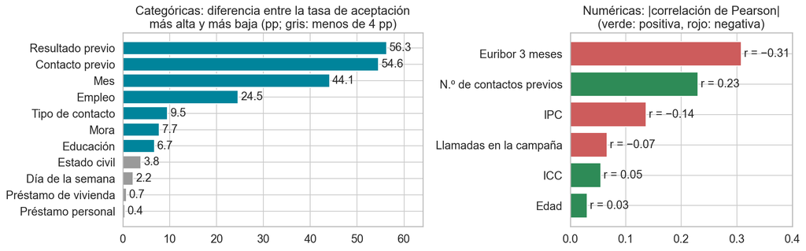

- **Historial:** resultado y contacto previo separan más de 54 puntos porcentuales la aceptación. **Momento:** el mes separa 44 pp y la Euribor es la numérica más fuerte (r = −0.31).
- Estado civil, día, vivienda y préstamo separan menos de 4 pp. Se mantienen las 17 variables: el árbol elige sus preguntas y la regularización reduce los coeficientes débiles.

## Modelos y métricas

Contexto · Preparación · **Modelado** · Evaluación · Explicabilidad · Autopsia · Conclusiones

**Árbol de decisión:** los patrones de la Parte I son cortes (tasa alta o baja, con o sin historial). Sus reglas se pueden leer y explicar.

**Regresión logística:** modelo lineal simple e interpretable. Sirve como punto de comparación.

- **Desbalance:** las clases se ponderan; cada cliente que acepta pesa unas 7.9 veces más (88.7 / 11.3).
- **Métrica de selección: F1 de la clase “Sí”**, que combina:
  - **Precision:** de cada 100 clientes que el modelo recomienda llamar, cuántos aceptan.
  - **Recall:** de cada 100 clientes que habrían aceptado, cuántos encuentra el modelo.
- La *accuracy* no sirve para elegir: responder siempre “No” daría 88.7%.

## Ajuste de hiperparámetros

Contexto · Preparación · **Modelado** · Evaluación · Explicabilidad · Autopsia · Conclusiones

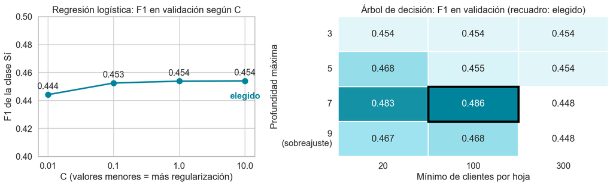

- **Búsqueda en grilla:** 16 combinaciones, evaluadas con el F1 en validación. Logística: C = 10 (F1 0.454); el F1 casi no cambia con C. Árbol: profundidad 7 y mínimo 100 clientes por hoja (F1 0.486).
- **Sobreajuste:** con profundidad 9 el F1 baja a 0.468; las reglas describen al entrenamiento y no a clientes nuevos. Con hojas de 300 clientes el árbol queda demasiado simple (0.448).

## Ajuste del umbral de decisión

Contexto · Preparación · **Modelado** · Evaluación · Explicabilidad · Autopsia · Conclusiones

**Umbral:** probabilidad mínima para recomendar la llamada (árbol: llamar si P(Sí) ≥ 0.55).

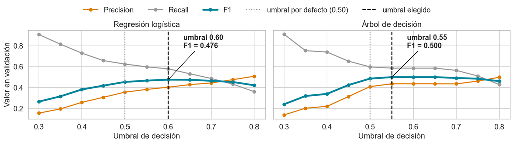

- Se probaron umbrales de 0.30 a 0.80 en validación. Subir el umbral: menos llamadas y más acertadas (sube la precision), pero se pierden interesados (baja el recall).
- Elegidos por mayor F1: **logística 0.60** (F1 0.476) y **árbol 0.55** (F1 0.500). Ambos superan 0.50 porque la ponderación de clases eleva las probabilidades de “Sí”.

## Resultados en el conjunto de prueba

Contexto · Preparación · Modelado · **Evaluación** · Explicabilidad · Autopsia · Conclusiones

| Modelo | Accuracy | Precision | Recall | F1 |
| --- | --- | --- | --- | --- |
| Árbol (0.55) | **0.872** | **0.449** | 0.596 | **0.512** |
| Logística (0.60) | 0.861 | 0.420 | **0.607** | 0.497 |

- **Accuracy:** ambos quedan debajo del 0.887 de responder siempre “No”, pero ese modelo no encuentra a ningún interesado.
- El F1 en prueba es similar al de validación: no hay sobreajuste.

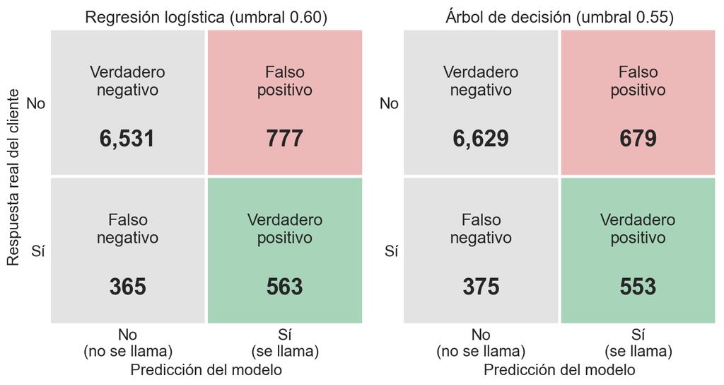

**Sin modelo:** acepta el 11.27% de los llamados. **Con el árbol:** acepta el 44.89%; se llama al 15% de la lista (1,232 clientes) y se captan 553 de los 928 interesados.

## Variables que usa cada modelo

Contexto · Preparación · Modelado · **Evaluación** · Explicabilidad · Autopsia · Conclusiones

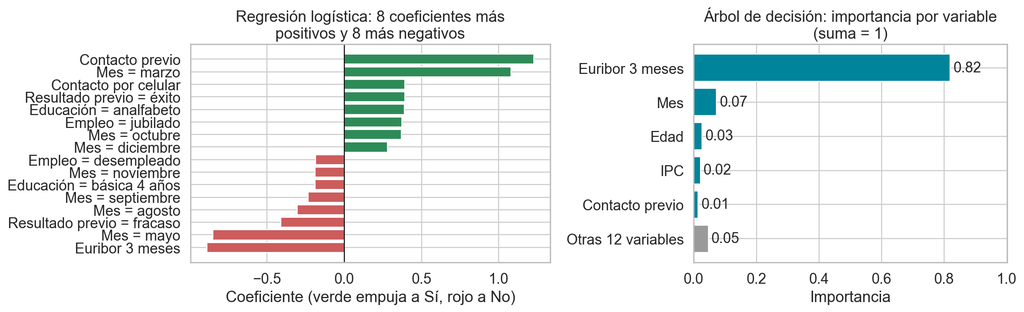

- Ambos modelos coinciden: Euribor, historial de contacto y mes.
- **Signo de la Euribor:** su coeficiente es negativo (−0.89 por desviación estándar): una tasa alta empuja hacia “No”. En un cliente con tasa **baja**, el aporte es **positivo**.
- El árbol concentra el **82%** de su importancia en la Euribor. Sus cortes (4.857, 4.860) identifican semanas específicas de la campaña.

## Árbol de decisión: primeros niveles

Contexto · Preparación · Modelado · Evaluación · **Explicabilidad** · Autopsia · Conclusiones

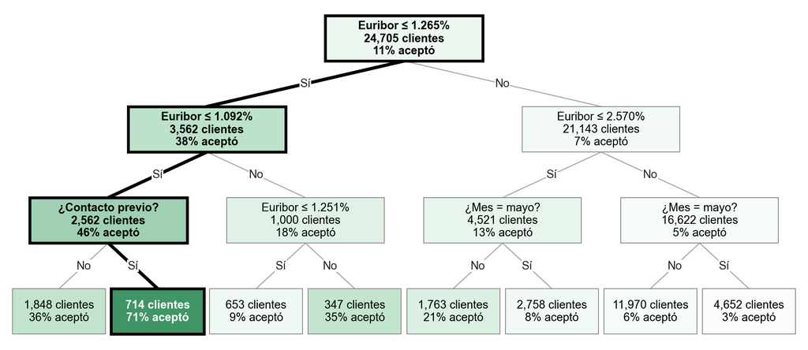

Línea gruesa: camino del Caso A (siguiente diapositiva). Color: % real de aceptación en entrenamiento (tasa general 11.3%). En niveles inferiores aparecen el número de llamadas y cortes finos de la Euribor.

## Caso clasificado correctamente: decisión paso a paso

Contexto · Preparación · Modelado · Evaluación · **Explicabilidad** · Autopsia · Conclusiones

**Caso A:** jubilado de 66 años, éxito previo, celular, marzo, Euribor 0.655%. **Aceptó.**

**Camino en el árbol**

1. Euribor = 0.655% ≤ 1.265%
2. Euribor = 0.655% ≤ 1.092%
3. Contacto previo = Sí
4. IPC = 93.369 > 92.681
5. Día distinto de lunes
6. Edad = 66 > 35.5
7. Llamadas en la campaña = 1 ≤ 1.5

Hoja 28: 101 clientes, 89.1% aceptó. P(Sí) = **0.985**.

**Regresión logística** (aporte = coeficiente × valor estandarizado)

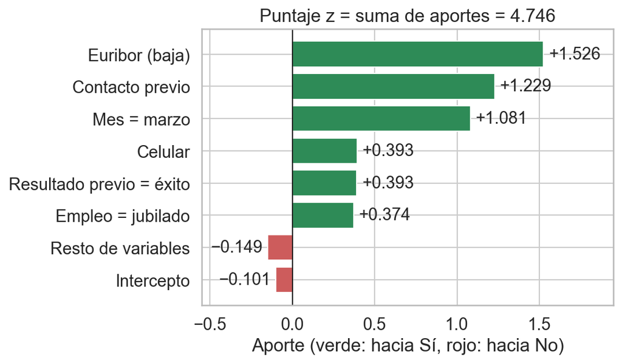

P(Sí) = 1 / (1 + e<sup>−4.746</sup>) = **0.991**

## Autopsia: errores del árbol de decisión

Contexto · Preparación · Modelado · Evaluación · Explicabilidad · **Autopsia** · Conclusiones

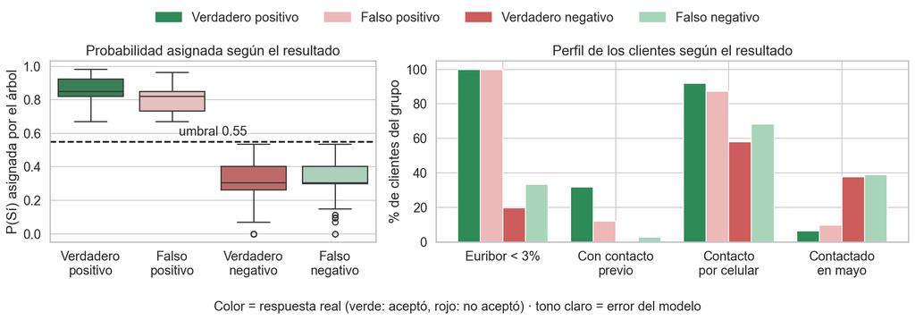

| Error | Casos | Consecuencia |
| --- | --- | --- |
| **Falso positivo** (Tipo I) | 679 | Llamada sin éxito |
| **Falso negativo** (Tipo II) | 375 | Depósito no captado |

- Los errores **no están cerca del umbral**: las cajas de los falsos positivos y negativos están lejos de la línea 0.55. El modelo no distingue estos clientes de los que clasifica bien.
- **Falsos positivos:** 100% con Euribor < 3%, pero solo 12% con contacto previo.
- **Falsos negativos:** aceptaron en condiciones desfavorables (39% en mayo).

## Dos casos fallidos

Contexto · Preparación · Modelado · Evaluación · Explicabilidad · **Autopsia** · Conclusiones

**Error 2 de 5: falso positivo (P(Sí) = 0.97)**

Jubilado de 56 años, contacto previo con resultado **fracaso**, celular, marzo, Euribor 0.644%. **No aceptó.**

- **Hipótesis:** en esa rama el árbol solo pregunta si hubo contacto previo, no cuál fue su resultado.
- **Solución:** combinar contacto previo y resultado previo en una sola variable (sin historial, fracaso, éxito).

**Error 5 de 5: falso negativo (P(Sí) = 0.00)**

Empleado de servicios de 52 años, teléfono fijo, mayo, Euribor 4.858%, 5 llamadas. **Aceptó.**

- **Hipótesis:** cae en una hoja que corresponde a una semana de mayo en la que ninguno de 128 clientes aceptó; su motivo no está en los datos.
- **Solución:** reemplazar el valor exacto de la Euribor por un nivel de tasas (baja o alta) y validar el modelo en el tiempo.

Los cinco errores analizados se concentran en dos hojas: el modelo depende más del **periodo** de la llamada que del **perfil** del cliente.

## Comparación y conclusiones

Contexto · Preparación · Modelado · Evaluación · Explicabilidad · Autopsia · **Conclusiones**

**Modelo elegido: árbol de decisión.** Mejor F1, mayor *precision* con un *recall* similar y reglas legibles.

|  | Árbol | Logística |
| --- | --- | --- |
| F1 (prueba) | **0.512** | 0.497 |
| Falsos positivos | **679** | 777 |
| Falsos negativos | 375 | **365** |
| Ventajas | Reglas legibles; capta cortes y combinaciones; no requiere estandarizar. | Estable ante el valor de C; un coeficiente resume cada variable; usa todas a la vez. |
| Limitaciones | Usa la Euribor como calendario (82% de importancia); probabilidades extremas en hojas pequeñas. | Efectos lineales y aditivos: no capta la forma en U de la edad ni combinaciones. |

**Conclusiones técnicas**

- El desbalance obligó a ponderar las clases y ajustar el umbral; aun así, el F1 se mantiene alrededor de 0.5.
- El rendimiento depende del contexto de tasas de 2008 a 2010.

**Mejoras de datos**

- Variables financieras del cliente: saldo, ingresos, endeudamiento y depósitos vigentes.
- Nivel de tasas, meses agrupados en temporadas y validación temporal.

## Consideraciones éticas

Contexto · Preparación · Modelado · Evaluación · Explicabilidad · Autopsia · **Conclusiones**

- **Privacidad:** el dataset contiene datos personales. Aplican el RGPD y, en Perú, la Ley N.º 29733; se requiere consentimiento.
- **Personas vulnerables:** el modelo prioriza a jubilados y adultos mayores. Se debe verificar que el producto sea adecuado para cada cliente.
- **Exclusión:** el modelo debe usarse para **ordenar** a quién llamar primero, no para **negar** el acceso al producto.
- **Costo de los errores:** con el umbral elegido no se encuentra al 40% de los interesados; el banco debe definir ese equilibrio.
- **Supervisión humana y monitoreo:** el modelo puede perder rendimiento si cambia el contexto económico.